# PRACTICAL 6(c): Data Analysis in R

In This Practical we will be doing basic data and Statistical analysis of Titanic Data set. The data set can be found on https://www.kaggle.com/c/titanic/data

# **1. Loading Data Set**

```r
train<- read.csv("C:/Users/ARSHDEEP SINGH/Downloads/train.csv")
head(train, 10)
```

|  | PassengerId | Survived | Pclass | Name | Sex | Age | SibSp | Parch | Ticket | Fare | Cabin | Embarked |
| --- | --- | --- | --- | --- | --- | --- | --- | --- | --- | --- | --- | --- |
| 1 | 1 | 0 | 3 | Braund, Mr. Owen Harris | male | 22 | 1 | 0 | A/5 21171 | 7.2500 |  | S |
| 2 | 2 | 1 | 1 | Cumings, Mrs. John Bradley (Florence Briggs Thayer) | female | 38 | 1 | 0 | PC 17599 | 71.2833 | C85 | C |
| 3 | 3 | 1 | 3 | Heikkinen, Miss. Laina | female | 26 | 0 | 0 | STON/O2. 3101282 | 7.9250 |  | S |
| 4 | 4 | 1 | 1 | Futrelle, Mrs. Jacques Heath (Lily May Peel) | female | 35 | 1 | 0 | 113803 | 53.1000 | C123 | S |
| 5 | 5 | 0 | 3 | Allen, Mr. William Henry | male | 35 | 0 | 0 | 373450 | 8.0500 |  | S |
| 6 | 6 | 0 | 3 | Moran, Mr. James | male | NA | 0 | 0 | 330877 | 8.4583 |  | Q |
| 7 | 7 | 0 | 1 | McCarthy, Mr. Timothy J | male | 54 | 0 | 0 | 17463 | 51.8625 | E46 | S |
| 8 | 8 | 0 | 3 | Palsson, Master. Gosta Leonard | male | 2 | 3 | 1 | 349909 | 21.0750 |  | S |
| 9 | 9 | 1 | 3 | Johnson, Mrs. Oscar W (Elisabeth Vilhelmina Berg) | female | 27 | 0 | 2 | 347742 | 11.1333 |  | S |
| 10 | 10 | 1 | 2 | Nasser, Mrs. Nicholas (Adele Achem) | female | 14 | 1 | 0 | 237736 | 30.0708 |  | C |

# Data Set Summary

```r
summary(train)
```

```
##   PassengerId       Survived          Pclass
##  Min.   :  1.0   Min.   :0.0000   Min.   :1.000
##  1st Qu.:223.5   1st Qu.:0.0000   1st Qu.:2.000
##  Median :446.0   Median :0.0000   Median :3.000
##  Mean   :446.0   Mean   :0.3838   Mean   :2.309
##  3rd Qu.:668.5   3rd Qu.:1.0000   3rd Qu.:3.000
##  Max.   :891.0   Max.   :1.0000   Max.   :3.000
##
##                                     Name         Sex           Age
##  Abbing, Mr. Anthony                  :  1   female:314   Min.   : 0.42
##  Abbott, Mr. Rossmore Edward          :  1   male  :577   1st Qu.:20.12
##  Abbott, Mrs. Stanton (Rosa Hunt)     :  1                Median :28.00
##  Abelson, Mr. Samuel                  :  1                Mean   :29.70
##  Abelson, Mrs. Samuel (Hannah Wizosky):  1                3rd Qu.:38.00
##  Adahl, Mr. Mauritz Nils Martin       :  1                Max.   :80.00
##  (Other)                              :885                NA's   :177
##      SibSp           Parch             Ticket         Fare
##  Min.   :0.000   Min.   :0.0000   1601    :  7   Min.   :  0.00
##  1st Qu.:0.000   1st Qu.:0.0000   347082  :  7   1st Qu.:  7.91
##  Median :0.000   Median :0.0000   CA. 2343:  7   Median : 14.45
##  Mean   :0.523   Mean   :0.3816   3101295 :  6   Mean   : 32.20
##  3rd Qu.:1.000   3rd Qu.:0.0000   347088  :  6   3rd Qu.: 31.00
##  Max.   :8.000   Max.   :6.0000   CA 2144 :  6   Max.   :512.33
##                                   (Other) :852
##          Cabin     Embarked
##             :687    :  2
##  B96 B98    :  4   C:168
##  C23 C25 C27:  4   Q: 77
##  G6         :  4   S:644
##  C22 C26    :  3
##  D          :  3
##  (Other)    :186
```

# Data set Dimension

```r
dim(train)
```

```
## [1] 891  12
```

**Let’s look deeper into the training set, and check how many passengers that survived vs did not make it.**

```r
table(train$Survived)
```

```
##
##   0   1
## 549 342
```

**Of the 891 there are only 342 who survived it. Check also as proportions.**

```r
prop.table(table(train$Survived))
```

```
##
##         0         1
## 0.6161616 0.3838384
```

**A little more than one-third of the passengers survived the disaster. Now see if there is a difference between males and females that survived vs males that passed away.**

```r
table(train$Sex, train$Survived)
```

```
##
##            0   1
##   female  81 233
##   male   468 109
```

# **2. Calculating Mean**

**Let’s find, the average value of Fare (variable in data set) charged to board Titanic Ship.**

```r
mean(train$Fare)
```

```
## [1] 32.20421
```

# **3. Mode**

**R does not have any inbuilt function to find out Mode. However, it does have a mode() function which returns the type or storage mode of an object instead. Let’s see how to find out the age with highest frequency**

```r
#using inbuild mode function
mode(train$Age)
```

```
## [1] "numeric"
```

```r
#using a simple method
actual_mode <- table(train$Age)    #creates a table of all age groups
```

```r
#view the output of actual_mode
actual_mode                        #let's treat the age values here as names
```

```
##
## 0.42 0.67 0.75 0.83 0.92    1    2    3    4    5    6    7    8    9   10
##    1    1    2    2    1    7   10    6   10    4    3    3    4    8    2
##   11   12   13   14 14.5   15   16   17   18   19   20 20.5   21   22   23
##    4    1    2    6    1    5   17   13   26   25   15    1   24   27   15
## 23.5   24 24.5   25   26   27   28 28.5   29   30 30.5   31   32 32.5   33
##    1   30    1   23   18   18   25    2   20   25    2   17   18    2   15
##   34 34.5   35   36 36.5   37   38   39   40 40.5   41   42   43   44   45
##   15    1   18   22    1    6   11   14   13    2    6   13    5    9   12
## 45.5   46   47   48   49   50   51   52   53   54   55 55.5   56   57   58
##    2    3    9    9    6   10    7    6    1    8    2    1    4    2    5
##   59   60   61   62   63   64   65   66   70 70.5   71   74   80
##    2    4    3    4    2    2    3    1    2    1    2    1    1
```

```r
#find the most frequent value using max
names(actual_mode)[actual_mode == max(actual_mode)]
```

```
## [1] "24"
```

*Interpretation: Most common age among passengers on Titanic was 24 years. As you can see, there were 30 passengers on board who are 24 years old (highest among all).*

# **4. Median**

**hink of ‘Median’ as the mid point of all values in data set. Median divides the data set into two equal halves such that one half is less than median and the other greater.**

**Median values are less affected by outliers. Also, it is based on all observations and easy to compute. Let’s compute the median of Fare.**

```r
#find out the median
median(train$Fare)
```

```
## [1] 14.4542
```

*Interpretation: The mid value of Fare variable is $14.45. This means $14.45 divides the data into two halves. If you compute its range, along with this statistic, you’ll find the this variable is highly skewed (don’t worry, if you don’t understand - we will discuss these terms shortly).*

# **5.Creating Histograph**

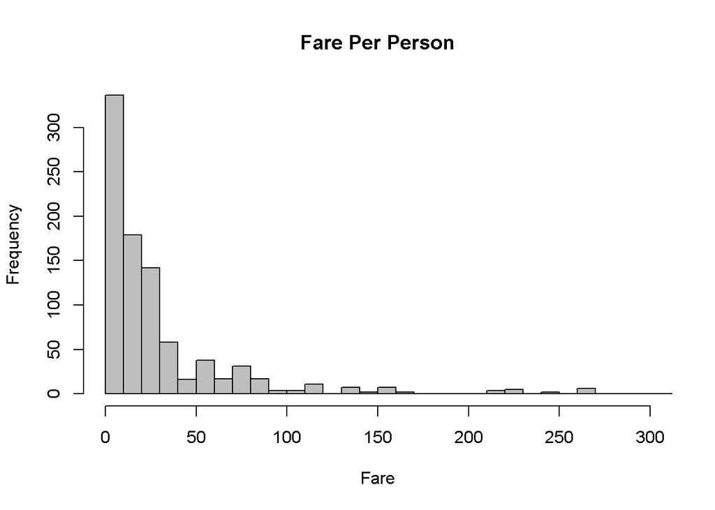

```r
#create bar chart of Fare
hist(train$Fare, main = "Fare Per Person", xlab = "Fare", col = "grey", breaks = 40, xlim = c(0,300))
```